# KNN Nearest Neighbor

The model that this data is based in is the Congressional voting data set from the Univeristy of Calirfornia Irvine Machine Learning Repository website.

Source:

Origin:

Congressional Quarterly Almanac, 98th Congress, 2nd session 1984, Volume XL: Congressional Quarterly Inc. Washington, D.C., 1985.

Donor:

Jeff Schlimmer (Jeffrey.Schlimmer '@' a.gp.cs.cmu.edu)

Data Set Information:

> This data set includes votes for each of the U.S. House of Representatives Congressmen on the 16 key votes identified by the CQA. The CQA lists nine different types of votes: voted for, paired for, and announced for (these three simplified to yea), voted against, paired against, and announced against (these three simplified to nay), voted present, voted present to avoid conflict of interest, and did not vote or otherwise make a position known (these three simplified to an unknown disposition).

Attribute Information:

1. Class Name: 2 (democrat, republican)
2. handicapped-infants: 2 (y,n)
3. water-project-cost-sharing: 2 (y,n)
4. adoption-of-the-budget-resolution: 2 (y,n)
5. physician-fee-freeze: 2 (y,n)
6. el-salvador-aid: 2 (y,n)
7. religious-groups-in-schools: 2 (y,n)
8. anti-satellite-test-ban: 2 (y,n)
9. aid-to-nicaraguan-contras: 2 (y,n)
10. mx-missile: 2 (y,n)
11. immigration: 2 (y,n)
12. synfuels-corporation-cutback: 2 (y,n)
13. education-spending: 2 (y,n)
14. superfund-right-to-sue: 2 (y,n)
15. crime: 2 (y,n)
16. duty-free-exports: 2 (y,n)
17. export-administration-act-south-africa: 2 (y,n)

Dua, D. and Karra Taniskidou, E. (2017). UCI Machine Learning Repository [http://archive.ics.uci.edu/ml]. Irvine, CA: University of California, School of Information and Computer Science.

```python
#Import Dependencies
import matplotlib.pyplot as plt
from sklearn.neighbors import KNeighborsClassifier
import pandas as pd
import numpy as np
```

```python
#Read in the data into a dataframe.
data = pd.read_table("house-votes-84.data", sep=",", header=None)
data
```

|  | 0 | 1 | 2 | 3 | 4 | 5 | 6 | 7 | 8 | 9 | 10 | 11 | 12 | 13 | 14 | 15 | 16 |
| --- | --- | --- | --- | --- | --- | --- | --- | --- | --- | --- | --- | --- | --- | --- | --- | --- | --- |
| 0 | republican | n | y | n | y | y | y | n | n | n | y | ? | y | y | y | n | y |
| 1 | republican | n | y | n | y | y | y | n | n | n | n | n | y | y | y | n | ? |
| 2 | democrat | ? | y | y | ? | y | y | n | n | n | n | y | n | y | y | n | n |
| 3 | democrat | n | y | y | n | ? | y | n | n | n | n | y | n | y | n | n | y |
| 4 | democrat | y | y | y | n | y | y | n | n | n | n | y | ? | y | y | y | y |
| 5 | democrat | n | y | y | n | y | y | n | n | n | n | n | n | y | y | y | y |
| 6 | democrat | n | y | n | y | y | y | n | n | n | n | n | n | ? | y | y | y |
| 7 | republican | n | y | n | y | y | y | n | n | n | n | n | n | y | y | ? | y |
| 8 | republican | n | y | n | y | y | y | n | n | n | n | n | y | y | y | n | y |
| 9 | democrat | y | y | y | n | n | n | y | y | y | n | n | n | n | n | ? | ? |
| 10 | republican | n | y | n | y | y | n | n | n | n | n | ? | ? | y | y | n | n |
| 11 | republican | n | y | n | y | y | y | n | n | n | n | y | ? | y | y | ? | ? |
| 12 | democrat | n | y | y | n | n | n | y | y | y | n | n | n | y | n | ? | ? |
| 13 | democrat | y | y | y | n | n | y | y | y | ? | y | y | ? | n | n | y | ? |
| 14 | republican | n | y | n | y | y | y | n | n | n | n | n | y | ? | ? | n | ? |
| 15 | republican | n | y | n | y | y | y | n | n | n | y | n | y | y | ? | n | ? |
| 16 | democrat | y | n | y | n | n | y | n | y | ? | y | y | y | ? | n | n | y |
| 17 | democrat | y | ? | y | n | n | n | y | y | y | n | n | n | y | n | y | y |
| 18 | republican | n | y | n | y | y | y | n | n | n | n | n | ? | y | y | n | n |
| 19 | democrat | y | y | y | n | n | n | y | y | y | n | y | n | n | n | y | y |
| 20 | democrat | y | y | y | n | n | ? | y | y | n | n | y | n | n | n | y | y |
| 21 | democrat | y | y | y | n | n | n | y | y | y | n | n | n | ? | ? | y | y |
| 22 | democrat | y | ? | y | n | n | n | y | y | y | n | n | ? | n | n | y | y |
| 23 | democrat | y | y | y | n | n | n | y | y | y | n | n | n | n | n | y | y |
| 24 | democrat | y | n | y | n | n | n | y | y | y | n | n | n | n | n | y | ? |
| 25 | democrat | y | n | y | n | n | n | y | y | y | y | n | n | n | n | y | y |
| 26 | democrat | y | n | y | n | n | n | y | y | y | n | y | n | n | n | y | y |
| 27 | democrat | y | y | y | n | n | n | y | y | y | n | y | n | n | n | y | y |
| 28 | republican | y | n | n | y | y | n | y | y | y | n | n | y | y | y | n | y |
| 29 | democrat | y | y | y | n | n | n | y | y | y | n | y | n | n | n | y | y |
| ... | ... | ... | ... | ... | ... | ... | ... | ... | ... | ... | ... | ... | ... | ... | ... | ... | ... |
| 405 | republican | n | n | n | y | y | y | n | n | n | n | n | y | y | y | n | y |
| 406 | democrat | y | n | y | n | y | y | n | n | y | y | n | n | y | y | n | y |
| 407 | democrat | n | n | n | y | y | y | n | n | n | n | y | y | y | y | n | n |
| 408 | democrat | y | n | y | n | n | y | y | y | y | n | n | y | ? | y | y | y |
| 409 | republican | n | n | n | y | y | y | n | n | n | n | n | y | y | y | n | n |
| 410 | republican | n | n | n | y | y | y | n | n | n | n | y | y | y | y | n | y |
| 411 | democrat | y | n | y | n | n | y | y | y | y | y | y | n | n | n | n | y |
| 412 | republican | n | n | n | y | y | y | n | n | n | y | n | y | y | y | n | y |
| 413 | republican | y | y | y | y | y | y | y | y | n | y | ? | ? | ? | y | n | y |
| 414 | democrat | y | y | y | n | n | n | y | y | y | n | n | n | n | n | n | y |
| 415 | democrat | n | y | y | n | n | y | y | y | ? | y | n | n | n | n | n | y |
| 416 | republican | y | y | n | y | y | y | n | n | n | y | n | n | y | y | n | y |
| 417 | democrat | y | y | y | n | n | n | y | y | y | y | y | n | y | n | n | y |
| 418 | democrat | y | y | y | n | n | n | y | y | n | y | n | n | n | n | n | y |
| 419 | democrat | y | y | y | n | n | n | y | y | y | n | n | n | n | n | n | y |
| 420 | republican | y | y | y | y | y | y | y | y | n | y | n | n | y | y | n | y |
| 421 | democrat | n | y | y | n | y | y | y | y | n | n | y | n | y | n | y | y |
| 422 | democrat | n | n | y | n | n | y | y | y | y | n | y | n | n | n | y | y |
| 423 | democrat | n | y | y | n | n | y | y | y | y | n | y | n | n | y | y | y |
| 424 | democrat | n | y | y | n | n | ? | y | y | y | y | y | n | ? | y | y | y |
| 425 | democrat | n | n | y | n | n | n | y | y | n | y | y | n | n | n | y | ? |
| 426 | democrat | y | n | y | n | n | n | y | y | y | y | n | n | n | n | y | y |
| 427 | republican | n | n | n | y | y | y | y | y | n | y | n | y | y | y | n | y |
| 428 | democrat | ? | ? | ? | n | n | n | y | y | y | y | n | n | y | n | y | y |
| 429 | democrat | y | n | y | n | ? | n | y | y | y | y | n | y | n | ? | y | y |
| 430 | republican | n | n | y | y | y | y | n | n | y | y | n | y | y | y | n | y |
| 431 | democrat | n | n | y | n | n | n | y | y | y | y | n | n | n | n | n | y |
| 432 | republican | n | ? | n | y | y | y | n | n | n | n | y | y | y | y | n | y |
| 433 | republican | n | n | n | y | y | y | ? | ? | ? | ? | n | y | y | y | n | y |
| 434 | republican | n | y | n | y | y | y | n | n | n | y | n | y | y | y | ? | n |

435 rows × 17 columns

```python
#Renamed the columns to show the title of the bills.
vote_names = data.rename(columns={0:"Party",1:"Disabled Infants",2:"Water Project Cost Sharing",3:"Adoption of the Budget Resolution",
                                  4:"Physician Fee Freeze",5:"El Salvador Aid",6:"Religious Groups is Schools",7:"Anti-Satellite Test Ban",
                                  8:"Aid to Nicaraguan Contras",9:"MX Missile",10:"Immigration", 11:"Synfuels Corporation Cutback",
                                  12:"Education Spending", 13:"Superfund Right to Sue", 14:"Crime",15:"Duty Free Exports",16:"Export Administration Act South Africa"})
vote_names
```

|  | Party | Disabled Infants | Water Project Cost Sharing | Adoption of the Budget Resolution | Physician Fee Freeze | El Salvador Aid | Religious Groups is Schools | Anti-Satellite Test Ban | Aid to Nicaraguan Contras | MX Missile | Immigration | Synfuels Corporation Cutback | Education Spending | Superfund Right to Sue | Crime | Duty Free Exports | Export Administration Act South Africa |
| --- | --- | --- | --- | --- | --- | --- | --- | --- | --- | --- | --- | --- | --- | --- | --- | --- | --- |
| 0 | republican | n | y | n | y | y | y | n | n | n | y | ? | y | y | y | n | y |
| 1 | republican | n | y | n | y | y | y | n | n | n | n | n | y | y | y | n | ? |
| 2 | democrat | ? | y | y | ? | y | y | n | n | n | n | y | n | y | y | n | n |
| 3 | democrat | n | y | y | n | ? | y | n | n | n | n | y | n | y | n | n | y |
| 4 | democrat | y | y | y | n | y | y | n | n | n | n | y | ? | y | y | y | y |
| 5 | democrat | n | y | y | n | y | y | n | n | n | n | n | n | y | y | y | y |
| 6 | democrat | n | y | n | y | y | y | n | n | n | n | n | n | ? | y | y | y |
| 7 | republican | n | y | n | y | y | y | n | n | n | n | n | n | y | y | ? | y |
| 8 | republican | n | y | n | y | y | y | n | n | n | n | n | y | y | y | n | y |
| 9 | democrat | y | y | y | n | n | n | y | y | y | n | n | n | n | n | ? | ? |
| 10 | republican | n | y | n | y | y | n | n | n | n | n | ? | ? | y | y | n | n |
| 11 | republican | n | y | n | y | y | y | n | n | n | n | y | ? | y | y | ? | ? |
| 12 | democrat | n | y | y | n | n | n | y | y | y | n | n | n | y | n | ? | ? |
| 13 | democrat | y | y | y | n | n | y | y | y | ? | y | y | ? | n | n | y | ? |
| 14 | republican | n | y | n | y | y | y | n | n | n | n | n | y | ? | ? | n | ? |
| 15 | republican | n | y | n | y | y | y | n | n | n | y | n | y | y | ? | n | ? |
| 16 | democrat | y | n | y | n | n | y | n | y | ? | y | y | y | ? | n | n | y |
| 17 | democrat | y | ? | y | n | n | n | y | y | y | n | n | n | y | n | y | y |
| 18 | republican | n | y | n | y | y | y | n | n | n | n | n | ? | y | y | n | n |
| 19 | democrat | y | y | y | n | n | n | y | y | y | n | y | n | n | n | y | y |
| 20 | democrat | y | y | y | n | n | ? | y | y | n | n | y | n | n | n | y | y |
| 21 | democrat | y | y | y | n | n | n | y | y | y | n | n | n | ? | ? | y | y |
| 22 | democrat | y | ? | y | n | n | n | y | y | y | n | n | ? | n | n | y | y |
| 23 | democrat | y | y | y | n | n | n | y | y | y | n | n | n | n | n | y | y |
| 24 | democrat | y | n | y | n | n | n | y | y | y | n | n | n | n | n | y | ? |
| 25 | democrat | y | n | y | n | n | n | y | y | y | y | n | n | n | n | y | y |
| 26 | democrat | y | n | y | n | n | n | y | y | y | n | y | n | n | n | y | y |
| 27 | democrat | y | y | y | n | n | n | y | y | y | n | y | n | n | n | y | y |
| 28 | republican | y | n | n | y | y | n | y | y | y | n | n | y | y | y | n | y |
| 29 | democrat | y | y | y | n | n | n | y | y | y | n | y | n | n | n | y | y |
| ... | ... | ... | ... | ... | ... | ... | ... | ... | ... | ... | ... | ... | ... | ... | ... | ... | ... |
| 405 | republican | n | n | n | y | y | y | n | n | n | n | n | y | y | y | n | y |
| 406 | democrat | y | n | y | n | y | y | n | n | y | y | n | n | y | y | n | y |
| 407 | democrat | n | n | n | y | y | y | n | n | n | n | y | y | y | y | n | n |
| 408 | democrat | y | n | y | n | n | y | y | y | y | n | n | y | ? | y | y | y |
| 409 | republican | n | n | n | y | y | y | n | n | n | n | n | y | y | y | n | n |
| 410 | republican | n | n | n | y | y | y | n | n | n | n | y | y | y | y | n | y |
| 411 | democrat | y | n | y | n | n | y | y | y | y | y | y | n | n | n | n | y |
| 412 | republican | n | n | n | y | y | y | n | n | n | y | n | y | y | y | n | y |
| 413 | republican | y | y | y | y | y | y | y | y | n | y | ? | ? | ? | y | n | y |
| 414 | democrat | y | y | y | n | n | n | y | y | y | n | n | n | n | n | n | y |
| 415 | democrat | n | y | y | n | n | y | y | y | ? | y | n | n | n | n | n | y |
| 416 | republican | y | y | n | y | y | y | n | n | n | y | n | n | y | y | n | y |
| 417 | democrat | y | y | y | n | n | n | y | y | y | y | y | n | y | n | n | y |
| 418 | democrat | y | y | y | n | n | n | y | y | n | y | n | n | n | n | n | y |
| 419 | democrat | y | y | y | n | n | n | y | y | y | n | n | n | n | n | n | y |
| 420 | republican | y | y | y | y | y | y | y | y | n | y | n | n | y | y | n | y |
| 421 | democrat | n | y | y | n | y | y | y | y | n | n | y | n | y | n | y | y |
| 422 | democrat | n | n | y | n | n | y | y | y | y | n | y | n | n | n | y | y |
| 423 | democrat | n | y | y | n | n | y | y | y | y | n | y | n | n | y | y | y |
| 424 | democrat | n | y | y | n | n | ? | y | y | y | y | y | n | ? | y | y | y |
| 425 | democrat | n | n | y | n | n | n | y | y | n | y | y | n | n | n | y | ? |
| 426 | democrat | y | n | y | n | n | n | y | y | y | y | n | n | n | n | y | y |
| 427 | republican | n | n | n | y | y | y | y | y | n | y | n | y | y | y | n | y |
| 428 | democrat | ? | ? | ? | n | n | n | y | y | y | y | n | n | y | n | y | y |
| 429 | democrat | y | n | y | n | ? | n | y | y | y | y | n | y | n | ? | y | y |
| 430 | republican | n | n | y | y | y | y | n | n | y | y | n | y | y | y | n | y |
| 431 | democrat | n | n | y | n | n | n | y | y | y | y | n | n | n | n | n | y |
| 432 | republican | n | ? | n | y | y | y | n | n | n | n | y | y | y | y | n | y |
| 433 | republican | n | n | n | y | y | y | ? | ? | ? | ? | n | y | y | y | n | y |
| 434 | republican | n | y | n | y | y | y | n | n | n | y | n | y | y | y | ? | n |

435 rows × 17 columns

```python
#Replaced the question marks with NaN using .replace().
vote_data = vote_names.replace("?", np.NaN)
vote_data
```

|  | Party | Disabled Infants | Water Project Cost Sharing | Adoption of the Budget Resolution | Physician Fee Freeze | El Salvador Aid | Religious Groups is Schools | Anti-Satellite Test Ban | Aid to Nicaraguan Contras | MX Missile | Immigration | Synfuels Corporation Cutback | Education Spending | Superfund Right to Sue | Crime | Duty Free Exports | Export Administration Act South Africa |
| --- | --- | --- | --- | --- | --- | --- | --- | --- | --- | --- | --- | --- | --- | --- | --- | --- | --- |
| 0 | republican | n | y | n | y | y | y | n | n | n | y | NaN | y | y | y | n | y |
| 1 | republican | n | y | n | y | y | y | n | n | n | n | n | y | y | y | n | NaN |
| 2 | democrat | NaN | y | y | NaN | y | y | n | n | n | n | y | n | y | y | n | n |
| 3 | democrat | n | y | y | n | NaN | y | n | n | n | n | y | n | y | n | n | y |
| 4 | democrat | y | y | y | n | y | y | n | n | n | n | y | NaN | y | y | y | y |
| 5 | democrat | n | y | y | n | y | y | n | n | n | n | n | n | y | y | y | y |
| 6 | democrat | n | y | n | y | y | y | n | n | n | n | n | n | NaN | y | y | y |
| 7 | republican | n | y | n | y | y | y | n | n | n | n | n | n | y | y | NaN | y |
| 8 | republican | n | y | n | y | y | y | n | n | n | n | n | y | y | y | n | y |
| 9 | democrat | y | y | y | n | n | n | y | y | y | n | n | n | n | n | NaN | NaN |
| 10 | republican | n | y | n | y | y | n | n | n | n | n | NaN | NaN | y | y | n | n |
| 11 | republican | n | y | n | y | y | y | n | n | n | n | y | NaN | y | y | NaN | NaN |
| 12 | democrat | n | y | y | n | n | n | y | y | y | n | n | n | y | n | NaN | NaN |
| 13 | democrat | y | y | y | n | n | y | y | y | NaN | y | y | NaN | n | n | y | NaN |
| 14 | republican | n | y | n | y | y | y | n | n | n | n | n | y | NaN | NaN | n | NaN |
| 15 | republican | n | y | n | y | y | y | n | n | n | y | n | y | y | NaN | n | NaN |
| 16 | democrat | y | n | y | n | n | y | n | y | NaN | y | y | y | NaN | n | n | y |
| 17 | democrat | y | NaN | y | n | n | n | y | y | y | n | n | n | y | n | y | y |
| 18 | republican | n | y | n | y | y | y | n | n | n | n | n | NaN | y | y | n | n |
| 19 | democrat | y | y | y | n | n | n | y | y | y | n | y | n | n | n | y | y |
| 20 | democrat | y | y | y | n | n | NaN | y | y | n | n | y | n | n | n | y | y |
| 21 | democrat | y | y | y | n | n | n | y | y | y | n | n | n | NaN | NaN | y | y |
| 22 | democrat | y | NaN | y | n | n | n | y | y | y | n | n | NaN | n | n | y | y |
| 23 | democrat | y | y | y | n | n | n | y | y | y | n | n | n | n | n | y | y |
| 24 | democrat | y | n | y | n | n | n | y | y | y | n | n | n | n | n | y | NaN |
| 25 | democrat | y | n | y | n | n | n | y | y | y | y | n | n | n | n | y | y |
| 26 | democrat | y | n | y | n | n | n | y | y | y | n | y | n | n | n | y | y |
| 27 | democrat | y | y | y | n | n | n | y | y | y | n | y | n | n | n | y | y |
| 28 | republican | y | n | n | y | y | n | y | y | y | n | n | y | y | y | n | y |
| 29 | democrat | y | y | y | n | n | n | y | y | y | n | y | n | n | n | y | y |
| ... | ... | ... | ... | ... | ... | ... | ... | ... | ... | ... | ... | ... | ... | ... | ... | ... | ... |
| 405 | republican | n | n | n | y | y | y | n | n | n | n | n | y | y | y | n | y |
| 406 | democrat | y | n | y | n | y | y | n | n | y | y | n | n | y | y | n | y |
| 407 | democrat | n | n | n | y | y | y | n | n | n | n | y | y | y | y | n | n |
| 408 | democrat | y | n | y | n | n | y | y | y | y | n | n | y | NaN | y | y | y |
| 409 | republican | n | n | n | y | y | y | n | n | n | n | n | y | y | y | n | n |
| 410 | republican | n | n | n | y | y | y | n | n | n | n | y | y | y | y | n | y |
| 411 | democrat | y | n | y | n | n | y | y | y | y | y | y | n | n | n | n | y |
| 412 | republican | n | n | n | y | y | y | n | n | n | y | n | y | y | y | n | y |
| 413 | republican | y | y | y | y | y | y | y | y | n | y | NaN | NaN | NaN | y | n | y |
| 414 | democrat | y | y | y | n | n | n | y | y | y | n | n | n | n | n | n | y |
| 415 | democrat | n | y | y | n | n | y | y | y | NaN | y | n | n | n | n | n | y |
| 416 | republican | y | y | n | y | y | y | n | n | n | y | n | n | y | y | n | y |
| 417 | democrat | y | y | y | n | n | n | y | y | y | y | y | n | y | n | n | y |
| 418 | democrat | y | y | y | n | n | n | y | y | n | y | n | n | n | n | n | y |
| 419 | democrat | y | y | y | n | n | n | y | y | y | n | n | n | n | n | n | y |
| 420 | republican | y | y | y | y | y | y | y | y | n | y | n | n | y | y | n | y |
| 421 | democrat | n | y | y | n | y | y | y | y | n | n | y | n | y | n | y | y |
| 422 | democrat | n | n | y | n | n | y | y | y | y | n | y | n | n | n | y | y |
| 423 | democrat | n | y | y | n | n | y | y | y | y | n | y | n | n | y | y | y |
| 424 | democrat | n | y | y | n | n | NaN | y | y | y | y | y | n | NaN | y | y | y |
| 425 | democrat | n | n | y | n | n | n | y | y | n | y | y | n | n | n | y | NaN |
| 426 | democrat | y | n | y | n | n | n | y | y | y | y | n | n | n | n | y | y |
| 427 | republican | n | n | n | y | y | y | y | y | n | y | n | y | y | y | n | y |
| 428 | democrat | NaN | NaN | NaN | n | n | n | y | y | y | y | n | n | y | n | y | y |
| 429 | democrat | y | n | y | n | NaN | n | y | y | y | y | n | y | n | NaN | y | y |
| 430 | republican | n | n | y | y | y | y | n | n | y | y | n | y | y | y | n | y |
| 431 | democrat | n | n | y | n | n | n | y | y | y | y | n | n | n | n | n | y |
| 432 | republican | n | NaN | n | y | y | y | n | n | n | n | y | y | y | y | n | y |
| 433 | republican | n | n | n | y | y | y | NaN | NaN | NaN | NaN | n | y | y | y | n | y |
| 434 | republican | n | y | n | y | y | y | n | n | n | y | n | y | y | y | NaN | n |

435 rows × 17 columns

## Due to the data being categorical, the "y" and "n" data points had to be transformed into indicator variables the numbers 1 for "y" and 0 for no in order for the model to work on the data. In order to do this the method "get_dummies()" was called on the dataframe. This step is called preprocessing.

```python
vote_data_encoded = pd.get_dummies(vote_data)
vote_data_encoded.head()
```

|  | Party_democrat | Party_republican | Disabled Infants_n | Disabled Infants_y | Water Project Cost Sharing_n | Water Project Cost Sharing_y | Adoption of the Budget Resolution_n | Adoption of the Budget Resolution_y | Physician Fee Freeze_n | Physician Fee Freeze_y | ... | Education Spending_n | Education Spending_y | Superfund Right to Sue_n | Superfund Right to Sue_y | Crime_n | Crime_y | Duty Free Exports_n | Duty Free Exports_y | Export Administration Act South Africa_n | Export Administration Act South Africa_y |
| --- | --- | --- | --- | --- | --- | --- | --- | --- | --- | --- | --- | --- | --- | --- | --- | --- | --- | --- | --- | --- | --- |
| 0 | 0 | 1 | 1 | 0 | 0 | 1 | 1 | 0 | 0 | 1 | ... | 0 | 1 | 0 | 1 | 0 | 1 | 1 | 0 | 0 | 1 |
| 1 | 0 | 1 | 1 | 0 | 0 | 1 | 1 | 0 | 0 | 1 | ... | 0 | 1 | 0 | 1 | 0 | 1 | 1 | 0 | 0 | 0 |
| 2 | 1 | 0 | 0 | 0 | 0 | 1 | 0 | 1 | 0 | 0 | ... | 1 | 0 | 0 | 1 | 0 | 1 | 1 | 0 | 1 | 0 |
| 3 | 1 | 0 | 1 | 0 | 0 | 1 | 0 | 1 | 1 | 0 | ... | 1 | 0 | 0 | 1 | 1 | 0 | 1 | 0 | 0 | 1 |
| 4 | 1 | 0 | 0 | 1 | 0 | 1 | 0 | 1 | 1 | 0 | ... | 0 | 0 | 0 | 1 | 0 | 1 | 0 | 1 | 0 | 1 |

5 rows × 34 columns

```python
#Indicating the target columns for the model.

target = vote_data_encoded[["Party_democrat","Party_republican"]]
target_names = ["Democrat", "Republican"]
```

## In order to avoid overfitting the data, we dropped the "no" responses from the data set. Only the "yes" responses were used to create the model.

```python
y_votes = vote_data_encoded.drop(["Disabled Infants_n","Water Project Cost Sharing_n", "Adoption of the Budget Resolution_n",
                            "Physician Fee Freeze_n", "El Salvador Aid_n","Religious Groups is Schools_n", "Anti-Satellite Test Ban_n", "Aid to Nicaraguan Contras_n","MX Missile_n","Immigration_n","Synfuels Corporation Cutback_n","Education Spending_n","Superfund Right to Sue_n",
                           "Crime_n", "Duty Free Exports_n","Export Administration Act South Africa_n" ], axis=1)
y_votes
```

|  | Party_democrat | Party_republican | Disabled Infants_y | Water Project Cost Sharing_y | Adoption of the Budget Resolution_y | Physician Fee Freeze_y | El Salvador Aid_y | Religious Groups is Schools_y | Anti-Satellite Test Ban_y | Aid to Nicaraguan Contras_y | MX Missile_y | Immigration_y | Synfuels Corporation Cutback_y | Education Spending_y | Superfund Right to Sue_y | Crime_y | Duty Free Exports_y | Export Administration Act South Africa_y |
| --- | --- | --- | --- | --- | --- | --- | --- | --- | --- | --- | --- | --- | --- | --- | --- | --- | --- | --- |
| 0 | 0 | 1 | 0 | 1 | 0 | 1 | 1 | 1 | 0 | 0 | 0 | 1 | 0 | 1 | 1 | 1 | 0 | 1 |
| 1 | 0 | 1 | 0 | 1 | 0 | 1 | 1 | 1 | 0 | 0 | 0 | 0 | 0 | 1 | 1 | 1 | 0 | 0 |
| 2 | 1 | 0 | 0 | 1 | 1 | 0 | 1 | 1 | 0 | 0 | 0 | 0 | 1 | 0 | 1 | 1 | 0 | 0 |
| 3 | 1 | 0 | 0 | 1 | 1 | 0 | 0 | 1 | 0 | 0 | 0 | 0 | 1 | 0 | 1 | 0 | 0 | 1 |
| 4 | 1 | 0 | 1 | 1 | 1 | 0 | 1 | 1 | 0 | 0 | 0 | 0 | 1 | 0 | 1 | 1 | 1 | 1 |
| 5 | 1 | 0 | 0 | 1 | 1 | 0 | 1 | 1 | 0 | 0 | 0 | 0 | 0 | 0 | 1 | 1 | 1 | 1 |
| 6 | 1 | 0 | 0 | 1 | 0 | 1 | 1 | 1 | 0 | 0 | 0 | 0 | 0 | 0 | 0 | 1 | 1 | 1 |
| 7 | 0 | 1 | 0 | 1 | 0 | 1 | 1 | 1 | 0 | 0 | 0 | 0 | 0 | 0 | 1 | 1 | 0 | 1 |
| 8 | 0 | 1 | 0 | 1 | 0 | 1 | 1 | 1 | 0 | 0 | 0 | 0 | 0 | 1 | 1 | 1 | 0 | 1 |
| 9 | 1 | 0 | 1 | 1 | 1 | 0 | 0 | 0 | 1 | 1 | 1 | 0 | 0 | 0 | 0 | 0 | 0 | 0 |
| 10 | 0 | 1 | 0 | 1 | 0 | 1 | 1 | 0 | 0 | 0 | 0 | 0 | 0 | 0 | 1 | 1 | 0 | 0 |
| 11 | 0 | 1 | 0 | 1 | 0 | 1 | 1 | 1 | 0 | 0 | 0 | 0 | 1 | 0 | 1 | 1 | 0 | 0 |
| 12 | 1 | 0 | 0 | 1 | 1 | 0 | 0 | 0 | 1 | 1 | 1 | 0 | 0 | 0 | 1 | 0 | 0 | 0 |
| 13 | 1 | 0 | 1 | 1 | 1 | 0 | 0 | 1 | 1 | 1 | 0 | 1 | 1 | 0 | 0 | 0 | 1 | 0 |
| 14 | 0 | 1 | 0 | 1 | 0 | 1 | 1 | 1 | 0 | 0 | 0 | 0 | 0 | 1 | 0 | 0 | 0 | 0 |
| 15 | 0 | 1 | 0 | 1 | 0 | 1 | 1 | 1 | 0 | 0 | 0 | 1 | 0 | 1 | 1 | 0 | 0 | 0 |
| 16 | 1 | 0 | 1 | 0 | 1 | 0 | 0 | 1 | 0 | 1 | 0 | 1 | 1 | 1 | 0 | 0 | 0 | 1 |
| 17 | 1 | 0 | 1 | 0 | 1 | 0 | 0 | 0 | 1 | 1 | 1 | 0 | 0 | 0 | 1 | 0 | 1 | 1 |
| 18 | 0 | 1 | 0 | 1 | 0 | 1 | 1 | 1 | 0 | 0 | 0 | 0 | 0 | 0 | 1 | 1 | 0 | 0 |
| 19 | 1 | 0 | 1 | 1 | 1 | 0 | 0 | 0 | 1 | 1 | 1 | 0 | 1 | 0 | 0 | 0 | 1 | 1 |
| 20 | 1 | 0 | 1 | 1 | 1 | 0 | 0 | 0 | 1 | 1 | 0 | 0 | 1 | 0 | 0 | 0 | 1 | 1 |
| 21 | 1 | 0 | 1 | 1 | 1 | 0 | 0 | 0 | 1 | 1 | 1 | 0 | 0 | 0 | 0 | 0 | 1 | 1 |
| 22 | 1 | 0 | 1 | 0 | 1 | 0 | 0 | 0 | 1 | 1 | 1 | 0 | 0 | 0 | 0 | 0 | 1 | 1 |
| 23 | 1 | 0 | 1 | 1 | 1 | 0 | 0 | 0 | 1 | 1 | 1 | 0 | 0 | 0 | 0 | 0 | 1 | 1 |
| 24 | 1 | 0 | 1 | 0 | 1 | 0 | 0 | 0 | 1 | 1 | 1 | 0 | 0 | 0 | 0 | 0 | 1 | 0 |
| 25 | 1 | 0 | 1 | 0 | 1 | 0 | 0 | 0 | 1 | 1 | 1 | 1 | 0 | 0 | 0 | 0 | 1 | 1 |
| 26 | 1 | 0 | 1 | 0 | 1 | 0 | 0 | 0 | 1 | 1 | 1 | 0 | 1 | 0 | 0 | 0 | 1 | 1 |
| 27 | 1 | 0 | 1 | 1 | 1 | 0 | 0 | 0 | 1 | 1 | 1 | 0 | 1 | 0 | 0 | 0 | 1 | 1 |
| 28 | 0 | 1 | 1 | 0 | 0 | 1 | 1 | 0 | 1 | 1 | 1 | 0 | 0 | 1 | 1 | 1 | 0 | 1 |
| 29 | 1 | 0 | 1 | 1 | 1 | 0 | 0 | 0 | 1 | 1 | 1 | 0 | 1 | 0 | 0 | 0 | 1 | 1 |
| ... | ... | ... | ... | ... | ... | ... | ... | ... | ... | ... | ... | ... | ... | ... | ... | ... | ... | ... |
| 405 | 0 | 1 | 0 | 0 | 0 | 1 | 1 | 1 | 0 | 0 | 0 | 0 | 0 | 1 | 1 | 1 | 0 | 1 |
| 406 | 1 | 0 | 1 | 0 | 1 | 0 | 1 | 1 | 0 | 0 | 1 | 1 | 0 | 0 | 1 | 1 | 0 | 1 |
| 407 | 1 | 0 | 0 | 0 | 0 | 1 | 1 | 1 | 0 | 0 | 0 | 0 | 1 | 1 | 1 | 1 | 0 | 0 |
| 408 | 1 | 0 | 1 | 0 | 1 | 0 | 0 | 1 | 1 | 1 | 1 | 0 | 0 | 1 | 0 | 1 | 1 | 1 |
| 409 | 0 | 1 | 0 | 0 | 0 | 1 | 1 | 1 | 0 | 0 | 0 | 0 | 0 | 1 | 1 | 1 | 0 | 0 |
| 410 | 0 | 1 | 0 | 0 | 0 | 1 | 1 | 1 | 0 | 0 | 0 | 0 | 1 | 1 | 1 | 1 | 0 | 1 |
| 411 | 1 | 0 | 1 | 0 | 1 | 0 | 0 | 1 | 1 | 1 | 1 | 1 | 1 | 0 | 0 | 0 | 0 | 1 |
| 412 | 0 | 1 | 0 | 0 | 0 | 1 | 1 | 1 | 0 | 0 | 0 | 1 | 0 | 1 | 1 | 1 | 0 | 1 |
| 413 | 0 | 1 | 1 | 1 | 1 | 1 | 1 | 1 | 1 | 1 | 0 | 1 | 0 | 0 | 0 | 1 | 0 | 1 |
| 414 | 1 | 0 | 1 | 1 | 1 | 0 | 0 | 0 | 1 | 1 | 1 | 0 | 0 | 0 | 0 | 0 | 0 | 1 |
| 415 | 1 | 0 | 0 | 1 | 1 | 0 | 0 | 1 | 1 | 1 | 0 | 1 | 0 | 0 | 0 | 0 | 0 | 1 |
| 416 | 0 | 1 | 1 | 1 | 0 | 1 | 1 | 1 | 0 | 0 | 0 | 1 | 0 | 0 | 1 | 1 | 0 | 1 |
| 417 | 1 | 0 | 1 | 1 | 1 | 0 | 0 | 0 | 1 | 1 | 1 | 1 | 1 | 0 | 1 | 0 | 0 | 1 |
| 418 | 1 | 0 | 1 | 1 | 1 | 0 | 0 | 0 | 1 | 1 | 0 | 1 | 0 | 0 | 0 | 0 | 0 | 1 |
| 419 | 1 | 0 | 1 | 1 | 1 | 0 | 0 | 0 | 1 | 1 | 1 | 0 | 0 | 0 | 0 | 0 | 0 | 1 |
| 420 | 0 | 1 | 1 | 1 | 1 | 1 | 1 | 1 | 1 | 1 | 0 | 1 | 0 | 0 | 1 | 1 | 0 | 1 |
| 421 | 1 | 0 | 0 | 1 | 1 | 0 | 1 | 1 | 1 | 1 | 0 | 0 | 1 | 0 | 1 | 0 | 1 | 1 |
| 422 | 1 | 0 | 0 | 0 | 1 | 0 | 0 | 1 | 1 | 1 | 1 | 0 | 1 | 0 | 0 | 0 | 1 | 1 |
| 423 | 1 | 0 | 0 | 1 | 1 | 0 | 0 | 1 | 1 | 1 | 1 | 0 | 1 | 0 | 0 | 1 | 1 | 1 |
| 424 | 1 | 0 | 0 | 1 | 1 | 0 | 0 | 0 | 1 | 1 | 1 | 1 | 1 | 0 | 0 | 1 | 1 | 1 |
| 425 | 1 | 0 | 0 | 0 | 1 | 0 | 0 | 0 | 1 | 1 | 0 | 1 | 1 | 0 | 0 | 0 | 1 | 0 |
| 426 | 1 | 0 | 1 | 0 | 1 | 0 | 0 | 0 | 1 | 1 | 1 | 1 | 0 | 0 | 0 | 0 | 1 | 1 |
| 427 | 0 | 1 | 0 | 0 | 0 | 1 | 1 | 1 | 1 | 1 | 0 | 1 | 0 | 1 | 1 | 1 | 0 | 1 |
| 428 | 1 | 0 | 0 | 0 | 0 | 0 | 0 | 0 | 1 | 1 | 1 | 1 | 0 | 0 | 1 | 0 | 1 | 1 |
| 429 | 1 | 0 | 1 | 0 | 1 | 0 | 0 | 0 | 1 | 1 | 1 | 1 | 0 | 1 | 0 | 0 | 1 | 1 |
| 430 | 0 | 1 | 0 | 0 | 1 | 1 | 1 | 1 | 0 | 0 | 1 | 1 | 0 | 1 | 1 | 1 | 0 | 1 |
| 431 | 1 | 0 | 0 | 0 | 1 | 0 | 0 | 0 | 1 | 1 | 1 | 1 | 0 | 0 | 0 | 0 | 0 | 1 |
| 432 | 0 | 1 | 0 | 0 | 0 | 1 | 1 | 1 | 0 | 0 | 0 | 0 | 1 | 1 | 1 | 1 | 0 | 1 |
| 433 | 0 | 1 | 0 | 0 | 0 | 1 | 1 | 1 | 0 | 0 | 0 | 0 | 0 | 1 | 1 | 1 | 0 | 1 |
| 434 | 0 | 1 | 0 | 1 | 0 | 1 | 1 | 1 | 0 | 0 | 0 | 1 | 0 | 1 | 1 | 1 | 0 | 0 |

435 rows × 18 columns

## This model is predicting the political party of members of Congress based on how each member voted. Since party is what is being predicted, we dropped the "Party_democrat" and "Party_republican" columns.

```python
voting_data = y_votes.drop(["Party_democrat", "Party_republican"], axis=1)
feature_names = voting_data.columns
voting_data.head()
```

|  | Disabled Infants_y | Water Project Cost Sharing_y | Adoption of the Budget Resolution_y | Physician Fee Freeze_y | El Salvador Aid_y | Religious Groups is Schools_y | Anti-Satellite Test Ban_y | Aid to Nicaraguan Contras_y | MX Missile_y | Immigration_y | Synfuels Corporation Cutback_y | Education Spending_y | Superfund Right to Sue_y | Crime_y | Duty Free Exports_y | Export Administration Act South Africa_y |
| --- | --- | --- | --- | --- | --- | --- | --- | --- | --- | --- | --- | --- | --- | --- | --- | --- |
| 0 | 0 | 1 | 0 | 1 | 1 | 1 | 0 | 0 | 0 | 1 | 0 | 1 | 1 | 1 | 0 | 1 |
| 1 | 0 | 1 | 0 | 1 | 1 | 1 | 0 | 0 | 0 | 0 | 0 | 1 | 1 | 1 | 0 | 0 |
| 2 | 0 | 1 | 1 | 0 | 1 | 1 | 0 | 0 | 0 | 0 | 1 | 0 | 1 | 1 | 0 | 0 |
| 3 | 0 | 1 | 1 | 0 | 0 | 1 | 0 | 0 | 0 | 0 | 1 | 0 | 1 | 0 | 0 | 1 |
| 4 | 1 | 1 | 1 | 0 | 1 | 1 | 0 | 0 | 0 | 0 | 1 | 0 | 1 | 1 | 1 | 1 |

## In this step we are splitting our data into test and training data. X is the dataframe"voting_data" and y is, "y_votes[["Party_democrat", "Party_republican"]]".

```python
from sklearn.model_selection import train_test_split

X = voting_data
y = y_votes[["Party_democrat", "Party_republican"]]

X_train, X_test, y_train, y_test = train_test_split(voting_data, target, random_state=42)
```

## This is where we run our KNN model. In the model we loop though different "k" values to see which one has the highest accuracy. We only use odd numbers in order to prevent ties.

```
k: 1, Train/Test Score: 1.000/0.936
k: 3, Train/Test Score: 0.966/0.927
k: 5, Train/Test Score: 0.948/0.927
k: 7, Train/Test Score: 0.929/0.917
k: 9, Train/Test Score: 0.933/0.927
k: 11, Train/Test Score: 0.929/0.917
k: 13, Train/Test Score: 0.936/0.917
k: 15, Train/Test Score: 0.926/0.899
k: 17, Train/Test Score: 0.933/0.908
k: 19, Train/Test Score: 0.926/0.899
```

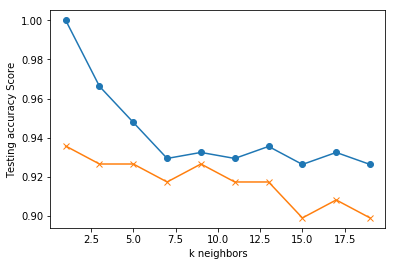

```python
# Loop through different k values to see which has the highest accuracy
# Note: We only use odd numbers because we don't want any ties
train_scores = []
test_scores = []
for k in range(1, 20, 2):
    knn = KNeighborsClassifier(n_neighbors=k)
    knn.fit(X_train, y_train)
    train_score = knn.score(X_train, y_train)
    test_score = knn.score(X_test, y_test)
    train_scores.append(train_score)
    test_scores.append(test_score)
    print(f"k: {k}, Train/Test Score: {train_score:.3f}/{test_score:.3f}")


plt.plot(range(1, 20, 2), train_scores, marker='o')
plt.plot(range(1, 20, 2), test_scores, marker="x")
plt.xlabel("k neighbors")
plt.ylabel("Testing accuracy Score")
plt.show()
```

## We chose k:5 because it was the best score before dropping. The last step is to fit the model using the best k score.

```python
#K:5 seems like the best score.

knn = KNeighborsClassifier(n_neighbors=5)
knn.fit(X_train, y_train)
print("k=5 Test Acc: %3f" % knn.score(X_test, y_test))
```

```
k=5 Test Acc: 0.926606
```

## k=5 Test Acc: 0.926606